# New_York_City_Restaurant_Opening

## Introduction/Business Problem

Recently, New York City (NYC) was ranked as the second best city for "Foodies", people who love food, by Wallethub.com. NYC was ranked this high due to the high density of restaurants, first in restaurants per capita, the high quality of the restaurants, and the diversity of the restaurants. On top of this, NYC was ranked 175 out of 180 by affordability. This would make NYC an attractive spot to open a restaurant. The city is known for having good restaurants and customers are already ready to pay high prices. The only problem is the difficulty in opening a succesful restaurant. Seeing this article, someone in New York hopes to open a restaurant but does not know in which borough to open. Most of all the person aims to avoid potential competition but also hopes to pay a small amount for rent and open in a borough where previous restaurants have been succesful.

## Data

This project will use Foursquare location data. This will allow for creating datasets that set apart different locations. The datasets will include proximity to other restauraunts. Restaurants in New York City will be separated by each borough. Additinally, a dataset obtained from the United States Census Burea will be used. The amount of money generated by food services and average amount of rent will be extracted from this dataset. Therefore, the final dataset will contain info on number of restaurants, total money grossed from the food industry, and average rent cost for each borough of New York City.

## Methodology

First, data was obtained from the Foursquare API. Thorugh this method, number of restaurants per borough was obtained. In order to normalize this data, restaurants per capita was calculated. Naturally, boroughs with more people will probably have more restaurants. Calculating the per capita values eliminates this bias. Along with this data, a dataframe was created containing the 'median gross rent' and the total accommodation and food services and sales. Once this dataframe was created a decision needed to be made. Therefore, a decision tree was made using algorithms in the sklearn library. This would help guide a potential person opening a restaurant in New York.

## Results

```python
final = pd.DataFrame(
    [(1000*bronx_num_res/1418207, 1.005, 1.176),
     (1000*bro_num_res/2559903, 2.453, 1.374),
     (1000*man_num_res/1628706, 20.382, 1.682),
     (1000*queens_num_res/2253858, 3.139, 1.520),
     (1000*staten_num_res/476143, .472, 1.282),
    ],
    index = ['Bronx', 'Brooklyn', 'Manhattan', 'Queens', 'Staten Island'],
    columns = ('RPC (for every thousand people)', 'TAF (per billion)', 'MGR (per thousand)')
)

final
```

|  | RPC (for every thousand people) | TAF (per billion) | MGR (per thousand) |
| --- | --- | --- | --- |
| Bronx | 0.129741 | 1.005 | 1.176 |
| Brooklyn | 0.135552 | 2.453 | 1.374 |
| Manhattan | 0.198317 | 20.382 | 1.682 |
| Queens | 0.175255 | 3.139 | 1.520 |
| Staten Island | 0.142814 | 0.472 | 1.282 |

The decision tree built can be seen below.

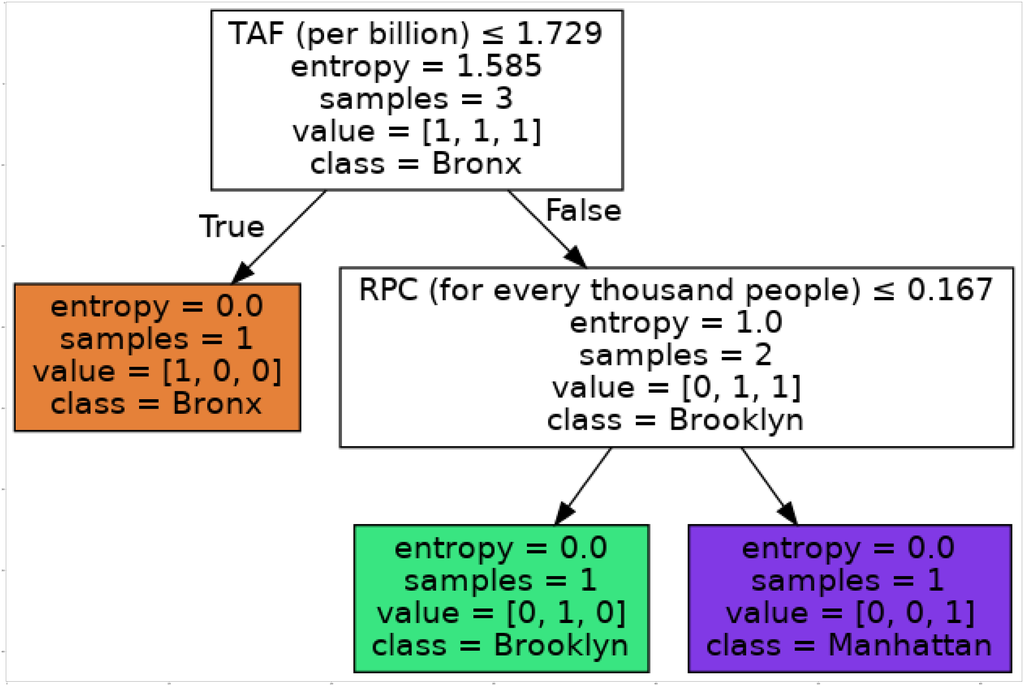

```python
dot_data = StringIO()
filename = "boroughtree.png"
featureNames = final.columns[0:3]
targetNames = final.index.unique().tolist()
out=tree.export_graphviz(boroughTree,feature_names=featureNames, out_file=dot_data, class_names= np.unique(y_trainset), filled=True,  special_characters=True,rotate=False)
graph = pydotplus.graph_from_dot_data(dot_data.getvalue())
graph.write_png(filename)
img = mpimg.imread(filename)
plt.figure(figsize=(100, 200))
plt.imshow(img,interpolation='nearest')
```

## Discussion

The decision tree built shows that a person opening a restaurant should consider the potential money they would make before making other decisions. The decision tree shows that this would eliminate the Bronx because the total grossed from the food and services industry in the bronx is below 1.729 billion. This means people may be less likely to spend money at restaurants in the Bronx. This also eliminates Staten Island, which has a less TAF than the Bronx. This leads to the second decision factor, restaurants per capita (RPC). A person who is looking to open with limited competition should choose somwhere with a lower amount pf restaurants. This separates Brooklyn and Manhattan as shown in the decision tree. Based on this decision tree, a potential restaurant owner should open their restaurant in Brooklyn. Not shown on the decision tree is Queens. While Queens does have a high TAF, its RPC is higher than Brooklyn. Therefore, Brooklyn remains the choice for the Borough in which to open a restaurant.

## Conclusion

Based on the analysis done above, Brooklyn would be the optimal borough in New York City in which to open a restaurant. Interestingly the machine learning algorithms chose TAF as the variable as the top indicator. This could be due to its values being naturally higher compared to the other data. In further research better attempts at normalizing data could be done to provide a better decision tree.

## Appendix

Importing necessary libraries for data retrieval and cleaning.

```python
import numpy as np
import pandas as pd
pd.set_option('display.max_columns', None)
pd.set_option('display.max_rows', None)

!conda install -c conda-forge geopy --yes
from geopy.geocoders import Nominatim

import json
import requests
from pandas.io.json import json_normalize
from bs4 import BeautifulSoup
```

[output not shown]

[output cut: 31 more lines]

[output not shown]

Download data

```python
!wget -q -O 'newyork_data.json' https://cocl.us/new_york_dataset
with open('newyork_data.json') as json_data:
    newyork_data = json.load(json_data)
```

Create dataframe based on the different Boroughs

```python
boroughs_data = newyork_data['features']
```

```python
column_names = ['Borough', 'Latitude','Longitude']
boroughs = pd.DataFrame(columns=column_names)
```

```python
for data in boroughs_data:
    borough = data['properties']['borough']

    coor = data['geometry']['coordinates']
    lat = coor[1]
    lng = coor[0]

    boroughs = boroughs.append({'Borough': borough, 'Latitude': lat, 'Longitude': lng}, ignore_index = True)
```

Credentials needed to use Foursquare API data.

```python
CLIENT_ID = '****'
CLIENT_SECRET = '*****'
VERSION = '20200818'
```

```python
address = 'New York City, NY'

geolocator = Nominatim(user_agent = "ny_explorer")
location = geolocator.geocode(address)

latitude = location.latitude
longitude = location.longitude
```

Create function for finding types of venues from Foursquare API.

```python
def get_category_type(row):
    try:
        categories_list = row['categories']
    except:
        categories_list = row['venue.categories']

    if len(categories_list) == 0:
        return None
    else:
        return categories_list[0]['name']
```

Separate the Bronx location data

```python
bronx_data = boroughs[boroughs['Borough'] == 'Bronx'].reset_index(drop = True)
```

Find all venues in the Bronx

```python
rad = 500
bronx_venues = pd.DataFrame()

for i, row in bronx_data.iterrows():
    lat = bronx_data.loc[i, 'Latitude']
    lng = bronx_data.loc[i, 'Longitude']
    url = 'https://api.foursquare.com/v2/venues/explore?&client_id={}&client_secret={}&v={}&ll={},{}&radius={}'.format(
    CLIENT_ID,
    CLIENT_SECRET,
    VERSION,
    lat,
    lng,
    rad)

    url

    result = requests.get(url).json()

    venues = result['response']['groups'][0]['items']

    nearby_venues = json_normalize(venues)

    filtered_columns = ['venue.name', 'venue.categories', 'venue.location.lat', 'venue.location.lng']
    nearby_venues = nearby_venues.loc[:, filtered_columns]

    nearby_venues['venue.categories'] = nearby_venues.apply(get_category_type, axis=1)
    nearby_venues.columns = [col.split(".")[-1] for col in nearby_venues.columns]

    for k, vals in nearby_venues.iterrows():
        venue_row = pd.Series(vals.values)
        bronx_venues = bronx_venues.append(venue_row, ignore_index = True)
```

Filter out all of the venues that aren't restaurants or are fast food restaurants.

```python
bronx_venues.rename(columns = {0: "Name", 1: "Category", 2: "Latitude", 3: "Longitude"}, inplace = True)
bronx_restaurants = bronx_venues[bronx_venues['Category'].str.contains('Restaurant')]
bronx_restaurants = bronx_restaurants[bronx_restaurants['Category'] != 'Fast Food Restaurant']
```

```python
bronx_restaurants
```

|  | Name | Category | Latitude | Longitude |
| --- | --- | --- | --- | --- |
| 17 | Townhouse Restaurant | Restaurant | 40.876086 | -73.828868 |
| 25 | Fish & Ting | Caribbean Restaurant | 40.885656 | -73.829197 |
| 28 | Dyre Fish Market | Seafood Restaurant | 40.889318 | -73.831453 |
| 30 | Golden Krust Caribbean Restaurant | Caribbean Restaurant | 40.888488 | -73.831083 |
| 33 | Royal Caribbean Bakery | Caribbean Restaurant | 40.888249 | -73.831661 |
| 64 | Leche y Miel | Latin American Restaurant | 40.883742 | -73.901857 |
| 66 | El Malecon | Caribbean Restaurant | 40.879338 | -73.904457 |
| 72 | El Economico Restaurant | Spanish Restaurant | 40.879330 | -73.904597 |
| 74 | Estrellita Poblana V | Mexican Restaurant | 40.879687 | -73.906257 |
| 77 | Picante Picante Mexican Restaurant | Mexican Restaurant | 40.878252 | -73.902936 |
| 78 | Q'Kachapa | Spanish Restaurant | 40.880006 | -73.904157 |
| 83 | Chipotle Mexican Grill | Mexican Restaurant | 40.884566 | -73.900474 |
| 95 | Patrizia's Of Woodlawn | Italian Restaurant | 40.900638 | -73.867724 |
| 96 | Curry Spot | Indian Restaurant | 40.897625 | -73.867147 |
| 124 | Queen of Tacos | Mexican Restaurant | 40.880200 | -73.883434 |
| 126 | V.I.P.'S Cafe | Restaurant | 40.881566 | -73.879299 |
| 130 | Golden Krust Caribbean Restaurant | Caribbean Restaurant | 40.881672 | -73.878996 |
| 135 | El Presidente II | Spanish Restaurant | 40.880516 | -73.883233 |
| 141 | Ming Liang Kitchen | Chinese Restaurant | 40.879876 | -73.876629 |
| 144 | Pine Deli | American Restaurant | 40.880340 | -73.883142 |
| 151 | The Dumplin Shop | Caribbean Restaurant | 40.884143 | -73.856449 |
| 153 | Caridad & Louie | Spanish Restaurant | 40.865843 | -73.837707 |
| 162 | Moe's Southwest Grill | Mexican Restaurant | 40.866310 | -73.830320 |
| 175 | Mr. Q's Chinese Restaurant | Chinese Restaurant | 40.855790 | -73.855455 |
| 176 | Enzo's | Italian Restaurant | 40.854232 | -73.854362 |
| 181 | Kiraku Hibachi & Sushi | Sushi Restaurant | 40.853356 | -73.853629 |
| 184 | Pasta Pasta | Italian Restaurant | 40.854788 | -73.854929 |
| 198 | Artie's Steak and Seafood | Italian Restaurant | 40.849542 | -73.787317 |
| 200 | Bistro SK | French Restaurant | 40.846387 | -73.786262 |
| 201 | Black Whale | American Restaurant | 40.846398 | -73.786438 |

[output cut: 154 more lines]

```python
manhattan_data = boroughs[boroughs['Borough'] == 'Manhattan'].reset_index(drop = True)
```

```python
rad = 500
manhattan_venues = pd.DataFrame()

for i, row in manhattan_data.iterrows():
    lat = manhattan_data.loc[i, 'Latitude']
    lng = manhattan_data.loc[i, 'Longitude']
    url = 'https://api.foursquare.com/v2/venues/explore?&client_id={}&client_secret={}&v={}&ll={},{}&radius={}'.format(
    CLIENT_ID,
    CLIENT_SECRET,
    VERSION,
    lat,
    lng,
    rad)

    url

    result = requests.get(url).json()

    venues = result['response']['groups'][0]['items']

    nearby_venues = json_normalize(venues)

    filtered_columns = ['venue.name', 'venue.categories', 'venue.location.lat', 'venue.location.lng']
    nearby_venues = nearby_venues.loc[:, filtered_columns]

    nearby_venues['venue.categories'] = nearby_venues.apply(get_category_type, axis=1)
    nearby_venues.columns = [col.split(".")[-1] for col in nearby_venues.columns]

    for k, vals in nearby_venues.iterrows():
        venue_row = pd.Series(vals.values)
        manhattan_venues = manhattan_venues.append(venue_row, ignore_index = True)
```

```python
manhattan_venues.rename(columns = {0: "Name", 1: "Category", 2: "Latitude", 3: "Longitude"}, inplace = True)
manhattan_restaurants = manhattan_venues[manhattan_venues['Category'].str.contains('Restaurant')]
manhattan_restaurants = manhattan_restaurants[manhattan_restaurants['Category'] != 'Fast Food Restaurant']
```

```python
manhattan_restaurants
```

|  | Name | Category | Latitude | Longitude |
| --- | --- | --- | --- | --- |
| 13 | Land & Sea Restaurant | Seafood Restaurant | 40.877885 | -73.905873 |
| 27 | Kiki's | Greek Restaurant | 40.714476 | -73.992036 |
| 29 | Spicy Village | Chinese Restaurant | 40.717010 | -73.993530 |
| 32 | Wah Fung Number 1 Fast Food 華豐快餐店 | Chinese Restaurant | 40.717278 | -73.994177 |
| 34 | Xi'an Famous Foods | Chinese Restaurant | 40.715232 | -73.997263 |
| 36 | Dimes | American Restaurant | 40.714830 | -73.991719 |
| 37 | Da Yu Hot Pot 大渝火锅 | Hotpot Restaurant | 40.716735 | -73.995752 |
| 38 | Forgtmenot | New American Restaurant | 40.714459 | -73.991546 |
| 43 | Cervo's | Spanish Restaurant | 40.714763 | -73.991455 |
| 48 | Happy Lamb Hot Pot, Manhattan | Hotpot Restaurant | 40.717639 | -73.995187 |
| 49 | Ling Kee | Asian Restaurant | 40.714713 | -73.991538 |
| 55 | The Uptown Garrison | Restaurant | 40.851255 | -73.939473 |
| 56 | Tampopo Ramen | Ramen Restaurant | 40.850693 | -73.936568 |
| 58 | Saggio Restaurant | Italian Restaurant | 40.851423 | -73.939761 |
| 68 | 181 Cabrini | New American Restaurant | 40.851251 | -73.940343 |
| 74 | The Pandering Pig | American Restaurant | 40.855226 | -73.937793 |
| 75 | Las Tapas | Tapas Restaurant | 40.855234 | -73.937284 |
| 79 | La Casa del Mofongo | Caribbean Restaurant | 40.850267 | -73.933145 |
| 80 | Kismat Indian Restaurant | Indian Restaurant | 40.855222 | -73.936967 |
| 82 | La Cabana Salvadorena | Latin American Restaurant | 40.854334 | -73.933677 |
| 83 | Terravita | New American Restaurant | 40.848059 | -73.937645 |
| 87 | Guadalupe Bar and Grill | Mexican Restaurant | 40.867334 | -73.920863 |
| 94 | fantastic lounge | Latin American Restaurant | 40.866297 | -73.919626 |
| 96 | The Tubby Hook | American Restaurant | 40.867816 | -73.920739 |
| 98 | Inwood Bar and Grill | Restaurant | 40.867044 | -73.922570 |
| 105 | Genesis Autentica Comida Ecuatoriana | Restaurant | 40.865498 | -73.919842 |
| 108 | La Reina Del Chicharron | Spanish Restaurant | 40.866357 | -73.925012 |
| 109 | Pick & Eat | American Restaurant | 40.867614 | -73.921253 |
| 110 | Made in Mexico | Mexican Restaurant | 40.867275 | -73.917090 |
| 112 | Guacamole | Mexican Restaurant | 40.869659 | -73.916736 |

[output cut: 293 more lines]

```python
queens_data = boroughs[boroughs['Borough'] == 'Queens'].reset_index(drop = True)
```

```python
rad = 500
queens_venues = pd.DataFrame()

for i, row in queens_data.iterrows():
    lat = queens_data.loc[i, 'Latitude']
    lng = queens_data.loc[i, 'Longitude']
    url = 'https://api.foursquare.com/v2/venues/explore?&client_id={}&client_secret={}&v={}&ll={},{}&radius={}'.format(
    CLIENT_ID,
    CLIENT_SECRET,
    VERSION,
    lat,
    lng,
    rad)

    url

    result = requests.get(url).json()

    venues = result['response']['groups'][0]['items']

    nearby_venues = json_normalize(venues)

    filtered_columns = ['venue.name', 'venue.categories', 'venue.location.lat', 'venue.location.lng']
    nearby_venues = nearby_venues.loc[:, filtered_columns]

    nearby_venues['venue.categories'] = nearby_venues.apply(get_category_type, axis=1)
    nearby_venues.columns = [col.split(".")[-1] for col in nearby_venues.columns]

    for k, vals in nearby_venues.iterrows():
        venue_row = pd.Series(vals.values)
        queens_venues = queens_venues.append(venue_row, ignore_index = True)
```

```python
queens_venues.rename(columns = {0: "Name", 1: "Category", 2: "Latitude", 3: "Longitude"}, inplace = True)
queens_restaurants = queens_venues[queens_venues['Category'].str.contains('Restaurant')]
queens_restaurants = queens_restaurants[queens_restaurants['Category'] != 'Fast Food Restaurant']
```

```python
queens_restaurants
```

|  | Name | Category | Latitude | Longitude |
| --- | --- | --- | --- | --- |
| 0 | Favela Grill | Brazilian Restaurant | 40.767348 | -73.917897 |
| 5 | Off The Hook | Seafood Restaurant | 40.767200 | -73.918104 |
| 6 | Al-sham Sweets and Pastries | Middle Eastern Restaurant | 40.768077 | -73.911561 |
| 10 | The Gully | Indian Restaurant | 40.766719 | -73.912410 |
| 11 | Sabry's | Seafood Restaurant | 40.768446 | -73.911267 |
| 12 | AbuQir Seafood | Seafood Restaurant | 40.768577 | -73.911169 |
| 13 | Duzan | Falafel Restaurant | 40.768730 | -73.911013 |
| 14 | SVL Bar | Greek Restaurant | 40.769816 | -73.918530 |
| 15 | Zyara Restaurant | Restaurant | 40.766591 | -73.912713 |
| 17 | El Cafetal | Mexican Restaurant | 40.770153 | -73.918214 |
| 21 | Seva Indian Cuisine | Indian Restaurant | 40.765521 | -73.919157 |
| 24 | Ovelia Psistaria Bar | Greek Restaurant | 40.765779 | -73.918890 |
| 25 | Jujube Tree | Vegetarian / Vegan Restaurant | 40.765309 | -73.918162 |
| 27 | Viva Viva | Mexican Restaurant | 40.765441 | -73.918768 |
| 30 | SriPraPhai | Thai Restaurant | 40.746342 | -73.899248 |
| 33 | Casa Del Chef Bistro | American Restaurant | 40.746174 | -73.899942 |
| 34 | Izalco | Latin American Restaurant | 40.746060 | -73.899753 |
| 36 | Thailand's Center Point | Thai Restaurant | 40.746531 | -73.900247 |
| 41 | Sweet Basil Thai | Thai Restaurant | 40.746484 | -73.903033 |
| 42 | Tropical Restaurant | Latin American Restaurant | 40.746155 | -73.897281 |
| 44 | Peking BBQ Chicken | Chinese Restaurant | 40.745488 | -73.906053 |
| 46 | Matsuri | Japanese Restaurant | 40.745626 | -73.903387 |
| 47 | Cafe Con Amor | American Restaurant | 40.746039 | -73.899441 |
| 48 | Woodside Cafe | American Restaurant | 40.744957 | -73.904179 |
| 50 | House of Inasal | Filipino Restaurant | 40.745986 | -73.898449 |
| 56 | La Abundancia | Arepa Restaurant | 40.749863 | -73.898791 |
| 60 | Oceanic Boil | Cajun / Creole Restaurant | 40.749952 | -73.881903 |
| 62 | Pollos a la Brasa Mario | Latin American Restaurant | 40.749806 | -73.883243 |
| 63 | El Chivito D' Oro | South American Restaurant | 40.749833 | -73.882376 |
| 64 | La Nueva Bakery | South American Restaurant | 40.750134 | -73.880227 |

[output cut: 365 more lines]

```python
brooklyn_data = boroughs[boroughs['Borough'] == 'Brooklyn'].reset_index(drop = True)
```

```python
rad = 500
brooklyn_venues = pd.DataFrame()

for i, row in brooklyn_data.iterrows():
    lat = brooklyn_data.loc[i, 'Latitude']
    lng = brooklyn_data.loc[i, 'Longitude']
    url = 'https://api.foursquare.com/v2/venues/explore?&client_id={}&client_secret={}&v={}&ll={},{}&radius={}'.format(
    CLIENT_ID,
    CLIENT_SECRET,
    VERSION,
    lat,
    lng,
    rad)

    url

    result = requests.get(url).json()

    venues = result['response']['groups'][0]['items']

    nearby_venues = json_normalize(venues)

    filtered_columns = ['venue.name', 'venue.categories', 'venue.location.lat', 'venue.location.lng']
    nearby_venues = nearby_venues.loc[:, filtered_columns]

    nearby_venues['venue.categories'] = nearby_venues.apply(get_category_type, axis=1)
    nearby_venues.columns = [col.split(".")[-1] for col in nearby_venues.columns]

    for k, vals in nearby_venues.iterrows():
        venue_row = pd.Series(vals.values)
        brooklyn_venues = brooklyn_venues.append(venue_row, ignore_index = True)
```

```python
brooklyn_venues.rename(columns = {0: "Name", 1: "Category", 2: "Latitude", 3: "Longitude"}, inplace = True)
brooklyn_restaurants = brooklyn_venues[brooklyn_venues['Category'].str.contains('Restaurant')]
brooklyn_restaurants = brooklyn_restaurants[brooklyn_restaurants['Category'] != 'Fast Food Restaurant']
```

```python
brooklyn_restaurants
```

|  | Name | Category | Latitude | Longitude |
| --- | --- | --- | --- | --- |
| 9 | Blue Door Souvlakia | Greek Restaurant | 40.624567 | -74.030311 |
| 11 | Karam | Middle Eastern Restaurant | 40.622931 | -74.028316 |
| 17 | Tuscany Grill | Italian Restaurant | 40.622913 | -74.031387 |
| 18 | Elia Restaurant | Greek Restaurant | 40.623090 | -74.031156 |
| 19 | Georgian Dream Cafe and Bakery | Caucasian Restaurant | 40.625586 | -74.030196 |
| 24 | Greenhouse Cafe | American Restaurant | 40.629542 | -74.028514 |
| 25 | XIN | Chinese Restaurant | 40.625082 | -74.030494 |
| 26 | Chadwick's Restaurant | American Restaurant | 40.621450 | -74.031964 |
| 27 | Cebu' Bar & Bistro | New American Restaurant | 40.621812 | -74.031727 |
| 28 | Zio Toto | Italian Restaurant | 40.624791 | -74.030551 |
| 30 | Villa Fiorita | Italian Restaurant | 40.611931 | -73.997854 |
| 32 | il Colosseo | Italian Restaurant | 40.612221 | -73.997436 |
| 35 | Tenzan | Sushi Restaurant | 40.615265 | -73.994046 |
| 38 | Hot Spot Nabe | Shabu-Shabu Restaurant | 40.615130 | -73.994582 |
| 42 | Wasabi | Sushi Restaurant | 40.614718 | -73.994751 |
| 43 | 18 Hipot | Hotpot Restaurant | 40.609241 | -74.000207 |
| 50 | Panda Chinese Restaurant | Chinese Restaurant | 40.611388 | -73.990784 |
| 55 | Home Town Restaurant | Chinese Restaurant | 40.614891 | -73.994881 |
| 60 | La Isla Cuchifritos | Latin American Restaurant | 40.645245 | -74.010200 |
| 61 | La Brasa Peruana | Latin American Restaurant | 40.646964 | -74.008443 |
| 64 | Tacos Matamoros | Mexican Restaurant | 40.647748 | -74.007621 |
| 74 | Ricos Tacos | Mexican Restaurant | 40.644426 | -74.010705 |
| 75 | International Restaurant | Latin American Restaurant | 40.648354 | -74.007086 |
| 77 | Cafe Lore | Italian Restaurant | 40.648474 | -74.010089 |
| 91 | Oxomoco | Mexican Restaurant | 40.729981 | -73.955460 |
| 92 | Karczma | Polish Restaurant | 40.730102 | -73.955092 |
| 93 | Friducha | Mexican Restaurant | 40.731512 | -73.954281 |
| 96 | Citroën | French Restaurant | 40.731173 | -73.954523 |
| 98 | Chiko | Szechuan Restaurant | 40.731871 | -73.954369 |
| 113 | Archestratus Books & Foods | Restaurant | 40.732905 | -73.955365 |

[output cut: 317 more lines]

```python
staten_data = boroughs[boroughs['Borough'] == 'Staten Island'].reset_index(drop = True)
```

```python
rad = 500
staten_venues = pd.DataFrame()

for i, row in staten_data.iterrows():
    lat = staten_data.loc[i, 'Latitude']
    lng = staten_data.loc[i, 'Longitude']
    url = 'https://api.foursquare.com/v2/venues/explore?&client_id={}&client_secret={}&v={}&ll={},{}&radius={}'.format(
    CLIENT_ID,
    CLIENT_SECRET,
    VERSION,
    lat,
    lng,
    rad)

    url

    result = requests.get(url).json()

    venues = result['response']['groups'][0]['items']

    nearby_venues = json_normalize(venues)

    filtered_columns = ['venue.name', 'venue.categories', 'venue.location.lat', 'venue.location.lng']
    nearby_venues = nearby_venues.loc[:, filtered_columns]

    nearby_venues['venue.categories'] = nearby_venues.apply(get_category_type, axis=1)
    nearby_venues.columns = [col.split(".")[-1] for col in nearby_venues.columns]

    for k, vals in nearby_venues.iterrows():
        venue_row = pd.Series(vals.values)
        staten_venues = staten_venues.append(venue_row, ignore_index = True)
```

[output not shown]

```python
staten_venues.rename(columns = {0: "Name", 1: "Category", 2: "Latitude", 3: "Longitude"}, inplace = True)
staten_restaurants = staten_venues[staten_venues['Category'].str.contains('Restaurant')]
staten_restaurants = staten_restaurants[staten_restaurants['Category'] != 'Fast Food Restaurant']
```

```python
staten_restaurants
```

|  | Name | Category | Latitude | Longitude |
| --- | --- | --- | --- | --- |
| 0 | Beso | Tapas Restaurant | 40.643306 | -74.076508 |
| 7 | Enoteca Maria | Italian Restaurant | 40.641941 | -74.077320 |
| 9 | Marie's 2 | Italian Restaurant | 40.642176 | -74.076669 |
| 10 | The Gavel Grill | American Restaurant | 40.642157 | -74.076674 |
| 26 | Papa's Halal Chicken & Kebab | Falafel Restaurant | 40.643683 | -74.077483 |
| 43 | Lakruwana | Sri Lankan Restaurant | 40.625654 | -74.075174 |
| 44 | Bay House Bistro | Asian Restaurant | 40.627827 | -74.076244 |
| 46 | Campo Bello Restaurante | Spanish Restaurant | 40.624463 | -74.079652 |
| 48 | El Patron Restaurant & Lounge Inc. | Mexican Restaurant | 40.629154 | -74.076541 |
| 53 | Vida | Restaurant | 40.628723 | -74.079802 |
| 67 | Bayou | Cajun / Creole Restaurant | 40.616853 | -74.068161 |
| 68 | Tony's Brick Oven Pizzeria | Italian Restaurant | 40.615180 | -74.067279 |
| 71 | Bin 5 | Italian Restaurant | 40.613278 | -74.065459 |
| 73 | Phil-Am Kusina | Filipino Restaurant | 40.612426 | -74.071455 |
| 74 | Korzo Klub | Eastern European Restaurant | 40.618819 | -74.069430 |
| 75 | Maizal | Mexican Restaurant | 40.618335 | -74.069547 |
| 78 | Convenient Food Mart | Restaurant | 40.612013 | -74.070612 |
| 87 | Yummy Taco | Mexican Restaurant | 40.616481 | -74.068183 |
| 91 | Molo | American Restaurant | 40.618391 | -74.069160 |
| 92 | Mazial | Mexican Restaurant | 40.618556 | -74.069469 |
| 96 | Panini Grill | Italian Restaurant | 40.630137 | -74.108156 |
| 100 | Burrito Bar | Mexican Restaurant | 40.630238 | -74.108776 |
| 109 | Cafe Milano | Italian Restaurant | 40.631014 | -74.102905 |
| 111 | Nürnberger Bierhaus | German Restaurant | 40.634765 | -74.109549 |
| 113 | Randall Manor Tavern | American Restaurant | 40.634736 | -74.107501 |
| 119 | Kyoto Sushi 5 | Japanese Restaurant | 40.630824 | -74.103289 |
| 145 | Bella Mama Rose Italian Restaurant | Italian Restaurant | 40.631772 | -74.146950 |
| 148 | bella mama rosa staten island | Italian Restaurant | 40.631750 | -74.147008 |
| 160 | Tokyo Sushi Japanese | Japanese Restaurant | 40.613121 | -74.120907 |
| 167 | How Greek Is It 2 | Restaurant | 40.613079 | -74.121753 |
| 168 | Spice Rack | Indian Restaurant | 40.613330 | -74.123173 |
| 175 | Holy Schnitzel | Restaurant | 40.589778 | -74.164390 |
| 179 | QDOBA Mexican Eats | Mexican Restaurant | 40.590926 | -74.164461 |
| 191 | Peking Taste IV | Chinese Restaurant | 40.590757 | -74.164559 |
| 192 | Island Kitchen | Chinese Restaurant | 40.590048 | -74.165303 |
| 194 | El Pollo II Restaurant | Spanish Restaurant | 40.590629 | -74.191982 |
| 210 | La Strada | Italian Restaurant | 40.573743 | -74.115627 |
| 213 | Taste Of India II | Indian Restaurant | 40.572127 | -74.112674 |
| 216 | Brioso | Italian Restaurant | 40.573052 | -74.114789 |
| 217 | Cantina Mexicana | Mexican Restaurant | 40.573802 | -74.116061 |
| 219 | Nori | Sushi Restaurant | 40.573737 | -74.117523 |
| 222 | Little Italy Gourmet | Italian Restaurant | 40.574565 | -74.116150 |
| 224 | Jade Asian Bistro | Dim Sum Restaurant | 40.571484 | -74.111447 |
| 227 | Pho Rainbow | Vietnamese Restaurant | 40.573792 | -74.116625 |
| 228 | Crown Palace | Chinese Restaurant | 40.572840 | -74.114302 |
| 240 | Arirang Hibachi Steakhouse | Japanese Restaurant | 40.549539 | -74.150123 |
| 243 | Piccolino's italian Restaurant | Italian Restaurant | 40.551538 | -74.149746 |
| 249 | Lucky Fortune Chinese Restaurant | Chinese Restaurant | 40.551275 | -74.150083 |
| 250 | La Candela Espanola | Spanish Restaurant | 40.551469 | -74.149436 |
| 253 | Benvenuti Pizzeria e Trattoria | Italian Restaurant | 40.551205 | -74.150175 |
| 258 | Gusto Restaurant | Italian Restaurant | 40.551670 | -74.149811 |
| 264 | Kiku Sushi | Sushi Restaurant | 40.544350 | -74.165691 |
| 270 | Giovannis Trattoria | Italian Restaurant | 40.545119 | -74.165951 |
| 272 | TOMO Japanese Cuisine | Sushi Restaurant | 40.542835 | -74.165578 |
| 282 | East Sushi | Sushi Restaurant | 40.545171 | -74.161357 |
| 284 | Aka Sushi | Sushi Restaurant | 40.545318 | -74.160197 |
| 290 | Tomo | Japanese Restaurant | 40.543011 | -74.165703 |
| 294 | Il Sogno | Restaurant | 40.541286 | -74.178489 |
| 295 | Angelos Pizza | American Restaurant | 40.540369 | -74.177033 |
| 303 | Misaki Sushi | Sushi Restaurant | 40.542515 | -74.207388 |
| 306 | QDOBA Mexican Eats | Mexican Restaurant | 40.542108 | -74.207452 |
| 319 | Islander Taste I | Chinese Restaurant | 40.542727 | -74.207586 |
| 322 | Don Cesar Mexican | Mexican Restaurant | 40.508984 | -74.246680 |
| 324 | Villaggio | Italian Restaurant | 40.509285 | -74.246597 |
| 330 | Taqueria El Gallo Azteca | Mexican Restaurant | 40.638402 | -74.078678 |
| 340 | Golden Krust Caribbean Bakery and Grill | Caribbean Restaurant | 40.637981 | -74.076454 |
| 346 | M&K Spanish Restaurant | Spanish Restaurant | 40.637543 | -74.076827 |
| 354 | The Veranda Cafe | American Restaurant | 40.622377 | -74.097934 |

Extracts total number of restaurants form each above dataframe.

```python
bronx_num_res = bronx_restaurants.shape[0]
man_num_res = manhattan_restaurants.shape[0]
queens_num_res = queens_restaurants.shape[0]
bro_num_res = brooklyn_restaurants.shape[0]
staten_num_res = staten_restaurants.shape[0]
```

Data from United States Census Bureau, https://www.census.gov/quickfacts/fact/table/newyorkcitynewyork,bronxcountybronxboroughnewyork,kingscountybrooklynboroughnewyork,newyorkcountymanhattanboroughnewyork,queenscountyqueensboroughnewyork,richmondcountystatenislandboroughnewyork/PST045219

```python
per_capita_restaurants = pd.DataFrame (
{
    "Bronx RPC": [bronx_num_res/1418207],
    "Brooklyn RPC": [bro_num_res/2559903],
    "Manhattan RPC": [man_num_res/1628706],
    "Queens RPC": [queens_num_res/2253858],
    "Staten Island RPC": [staten_num_res/476143],
}
)
```

```python
per_capita_restaurants
```

|  | Bronx RPC | Brooklyn RPC | Manhattan RPC | Queens RPC | Staten Island RPC |
| --- | --- | --- | --- | --- | --- |
| 0 | 0.00013 | 0.000136 | 0.000198 | 0.000175 | 0.000143 |

restaurants per capita, total accomodation and food services (per billion), median gross rent

Import libraries to create a decision tree.

```python
from sklearn.tree import DecisionTreeClassifier
from sklearn.model_selection import train_test_split
```

Create training and testing datasets.

```python
y = final.index
X = final[['RPC (for every thousand people)', 'TAF (per billion)', 'MGR (per thousand)']].values
```

```python
X_trainset, X_testset, y_trainset, y_testset = train_test_split(X, y, test_size=0.3, random_state=3)
```

Create decision tree

```python
boroughTree = DecisionTreeClassifier(criterion="entropy", max_depth = 4)
```

```python
boroughTree.fit(X_trainset,y_trainset)
```

```
DecisionTreeClassifier(class_weight=None, criterion='entropy', max_depth=4,
            max_features=None, max_leaf_nodes=None,
            min_impurity_decrease=0.0, min_impurity_split=None,
            min_samples_leaf=1, min_samples_split=2,
            min_weight_fraction_leaf=0.0, presort=False, random_state=None,
            splitter='best')
```

Import plotting libraries

```python
!conda install -c conda-forge pydotplus -y
!conda install -c conda-forge python-graphviz -y
```

```python
from sklearn.externals.six import StringIO
import pydotplus
import matplotlib.image as mpimg
from sklearn import tree
%matplotlib inline
import matplotlib.pyplot as plt
```